# DE Analysis with Seurat

```r
suppressPackageStartupMessages(library(Seurat))
suppressPackageStartupMessages(library(SeuratData))
suppressPackageStartupMessages(library(ggplot2))
```

```r
load("data/SC26_FMTG_FILTERED_CLUSTERS_ANNOTATED.rda")
```

```r
head(sobj)
```

```
                   orig.ident nCount_RNA nFeature_RNA percent_mt doublets.class
AAACCCAAGAAGCGGG-1  SC26_FMTG       3561         1510   13.50744        singlet
AAACCCAAGAGGGTCT-1  SC26_FMTG       3540         1253   17.37288        singlet
AAACCCACAAGAGTTA-1  SC26_FMTG       5825         2004   13.80258        singlet
AAACCCACAATTCACG-1  SC26_FMTG       5586         1520   26.31579        singlet
AAACCCACATTGCCTC-1  SC26_FMTG       2450          848   29.34694        singlet
AAACCCATCAAGGACG-1  SC26_FMTG      41318         5564   16.87884        singlet
AAACCCATCGACCTAA-1  SC26_FMTG      62288         6005   17.33239        singlet
AAACCCATCTCACTCG-1  SC26_FMTG       8379         1568   29.28750        singlet
AAACGAAAGCTCCACG-1  SC26_FMTG       3632         1176   26.45925        singlet
AAACGAACAGTTGTTG-1  SC26_FMTG       2260         1030   13.98230        singlet
                   nCount_SCT nFeature_SCT RNA_snn_res.0.1 RNA_snn_res.0.2
AAACCCAAGAAGCGGG-1       4497         1503               0               0
AAACCCAAGAGGGTCT-1       4562         1242               2               2
AAACCCACAAGAGTTA-1       5327         1998               0               0
AAACCCACAATTCACG-1       5195         1515               2               2
AAACCCACATTGCCTC-1       4717          888               1               1
AAACCCATCAAGGACG-1       5219         1818               1               1
AAACCCATCGACCTAA-1       5262         1810               1               1
AAACCCATCTCACTCG-1       5423         1497               1               1
AAACGAAAGCTCCACG-1       4600         1169               2               2
AAACGAACAGTTGTTG-1       4513         1061               1               1
                   RNA_snn_res.0.5 RNA_snn_res.1 seurat_clusters     S.Score
AAACCCAAGAAGCGGG-1               0             2               2  0.01314952
AAACCCAAGAGGGTCT-1               1             5               5 -0.02692184
AAACCCACAAGAGTTA-1               0             2               2 -0.02844730
AAACCCACAATTCACG-1               1             1               1 -0.01524386
AAACCCACATTGCCTC-1               4             7               7 -0.04336199
AAACCCATCAAGGACG-1               8            12              12 -0.04580372
AAACCCATCGACCTAA-1               2             8               8 -0.05640533
AAACCCATCTCACTCG-1               4             7               7 -0.04025687
AAACGAAAGCTCCACG-1               1             1               1 -0.02645379
AAACGAACAGTTGTTG-1               6             6               6 -0.04555313
                      G2M.Score Phase old.ident RNA_snn_res.0.5_annot
AAACCCAAGAAGCGGG-1 -0.031395488     S         0                   CD8
AAACCCAAGAGGGTCT-1 -0.026506131    G1         1               B_cells
AAACCCACAAGAGTTA-1 -0.025530720    G1         0                   CD8
AAACCCACAATTCACG-1 -0.023530238    G1         1               B_cells
AAACCCACATTGCCTC-1 -0.044640446    G1         4            Enterocyte
AAACCCATCAAGGACG-1 -0.046687734    G1         8        ? Stem_or_Tuft
AAACCCATCGACCTAA-1 -0.078550926    G1         2            Enterocyte
AAACCCATCTCACTCG-1 -0.044713075    G1         4            Enterocyte
AAACGAAAGCTCCACG-1 -0.003504353    G1         1               B_cells
AAACGAACAGTTGTTG-1 -0.037852041    G1         6            Enterocyte
```

```r
table(sobj$RNA_snn_res.0.5_annot)
```

```
                   CD8                B_cells             Enterocyte
                  1089                    734                    771
             CD4_naive         ? Stem_or_Tuft             CD4_memory
                   352                     73                     71
                Goblet           ? Enterocyte ? Enterocyte or Goblet
                    45                     39                     20
```

Based on the annotated data, we can then perform:

- Default single cell level DE analysis
  - between two cell types
  - one cell type against the others
- Compare expression between conditions within the same cell type
  - single cell level (ignore the correlation between cells from the same sample)
  - pseudo-bulk DE analysis

## Default DE Analysis

The Wilcoxon Rank Sum test is used as default.

```r
## set indentity if not done yet
# Idents(sobj) <- "RNA_snn_res.0.5_annot"

# identify DE features between CD8 and CD4_naive
cd8.cd4.de.markers <- FindMarkers(sobj, ident.1 = "CD8", ident.2 = "CD4_naive")
```

[output not shown]

```r
head(cd8.cd4.de.markers)
```

```
               p_val avg_log2FC pct.1 pct.2     p_val_adj
Ms4a4b 1.540843e-190  -4.494075 0.083 0.861 2.549478e-186
Slamf6 5.010280e-152  -7.960414 0.005 0.568 8.290010e-148
Tcf7   1.902241e-149  -4.714542 0.047 0.679 3.147448e-145
Gzma   2.074832e-144   4.499937 0.956 0.438 3.433016e-140
Cd7    1.368972e-143   3.357909 0.966 0.295 2.265101e-139
Lef1   1.588334e-143  -6.904152 0.011 0.560 2.628057e-139
```

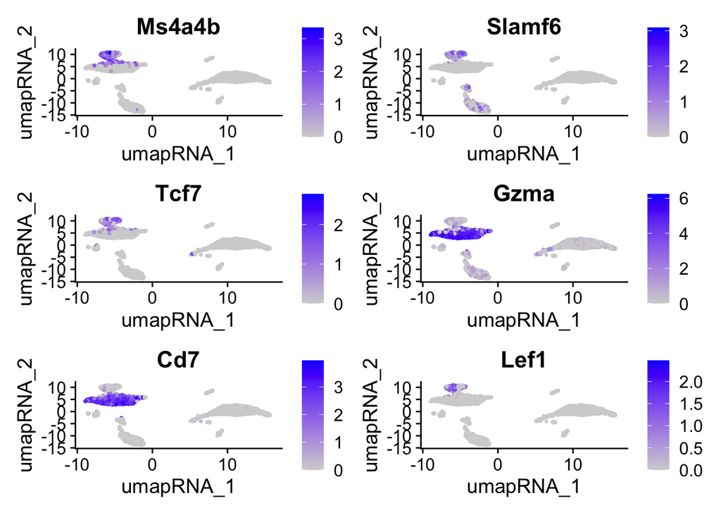

```r
FeaturePlot(object = sobj, features = head(rownames(cd8.cd4.de.markers)))
```

If the `ident.2` parameter is omitted or set to `NULL`, `FindMarkers()` will test for differentially expressed features between the group specified by ident.1 and all other cells.

```r
cd8.de.markers <- FindMarkers(sobj, ident.1 = "CD8", ident.2 = NULL)

head(cd8.de.markers)
```

```
      p_val avg_log2FC pct.1 pct.2 p_val_adj
Nkg7      0   4.810807 0.971 0.089         0
Cd7       0   5.617666 0.966 0.086         0
Cd8a      0   5.277699 0.914 0.057         0
Itgae     0   4.891623 0.907 0.052         0
Ctsw      0   4.776672 0.904 0.062         0
Itga1     0   4.804223 0.899 0.074         0
```

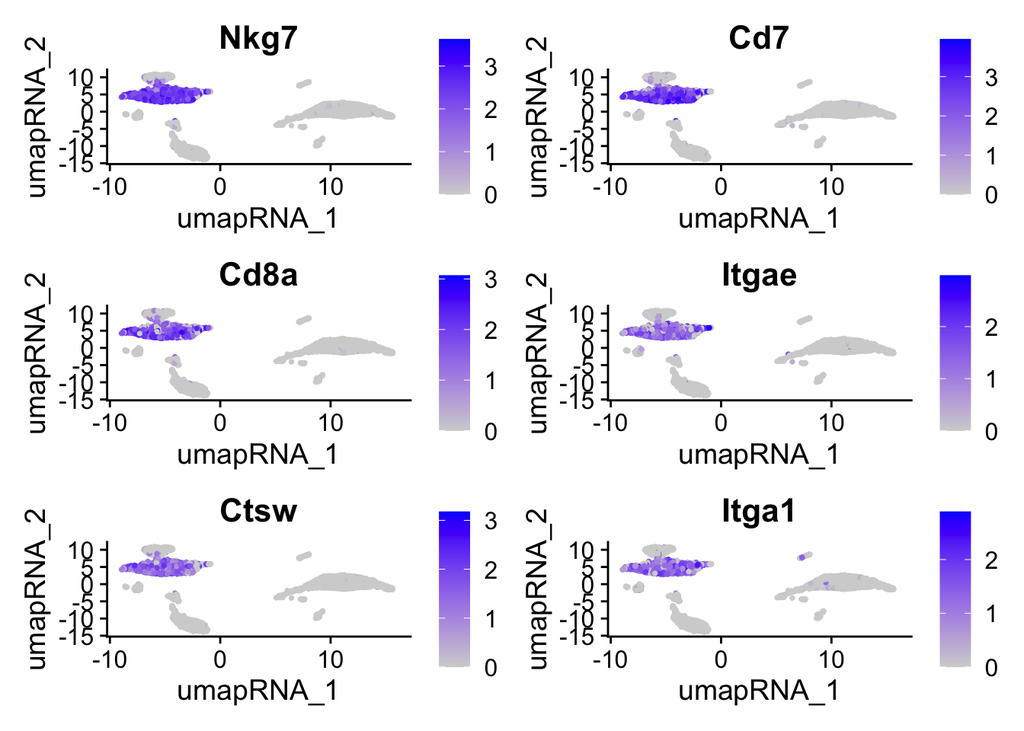

```r
FeaturePlot(object = sobj, features = head(rownames(cd8.de.markers)))
```

## Compare expression between conditions

The first way is to compare gene expression between conditions within the same cell type.

You just need to create a new Ident which combines the information of cell type and conditions.

```r
# aa <- SeuratData::AvailableData()
# aa[which(aa$Dataset == "ifnb"), ]
# SeuratData::InstallData("ifnb") # error: no pkg called 'ifnb.SeuratData'
## try to install from source
# install.packages(
#   "https://seurat.nygenome.org/src/contrib/ifnb.SeuratData_3.0.0.tar.gz",
#   repos = NULL, type = "source"
# )
suppressPackageStartupMessages(library(ifnb.SeuratData))
ifnb <- LoadData("ifnb")
```

```
Validating object structure
```

```
Updating object slots
```

```
Ensuring keys are in the proper structure
```

```
Ensuring keys are in the proper structure
```

```
Ensuring feature names don't have underscores or pipes
```

```
Updating slots in RNA
```

```
Validating object structure for Assay 'RNA'
```

```
Object representation is consistent with the most current Seurat version
```

```r
head(ifnb)
```

```
                  orig.ident nCount_RNA nFeature_RNA stim seurat_annotations
AAACATACATTTCC.1 IMMUNE_CTRL       3017          877 CTRL          CD14 Mono
AAACATACCAGAAA.1 IMMUNE_CTRL       2481          713 CTRL          CD14 Mono
AAACATACCTCGCT.1 IMMUNE_CTRL       3420          850 CTRL          CD14 Mono
AAACATACCTGGTA.1 IMMUNE_CTRL       3156         1109 CTRL                pDC
AAACATACGATGAA.1 IMMUNE_CTRL       1868          634 CTRL       CD4 Memory T
AAACATACGGCATT.1 IMMUNE_CTRL       1581          557 CTRL          CD14 Mono
AAACATACTGCGTA.1 IMMUNE_CTRL       2747          980 CTRL        T activated
AAACATACTGCTGA.1 IMMUNE_CTRL       1341          581 CTRL        CD4 Naive T
AAACATTGAGTGTC.1 IMMUNE_CTRL       2155          880 CTRL              CD8 T
AAACATTGCTTCGC.1 IMMUNE_CTRL       2536          669 CTRL          CD14 Mono
```

```r
table(ifnb$stim, ifnb$seurat_annotations)
```

```
       CD14 Mono CD4 Naive T CD4 Memory T CD16 Mono    B CD8 T T activated   NK
  CTRL      2215         978          859       507  407   352         300  298
  STIM      2147        1526          903       537  571   462         333  321

         DC B Activated   Mk  pDC Eryth
  CTRL  258         185  115   51    23
  STIM  214         203  121   81    32
```

```r
# create a new identity
ifnb$celltype.stim <- paste(ifnb$seurat_annotations, ifnb$stim, sep = "_")
Idents(ifnb) <- "celltype.stim"
head(ifnb)
```

```
                  orig.ident nCount_RNA nFeature_RNA stim seurat_annotations
AAACATACATTTCC.1 IMMUNE_CTRL       3017          877 CTRL          CD14 Mono
AAACATACCAGAAA.1 IMMUNE_CTRL       2481          713 CTRL          CD14 Mono
AAACATACCTCGCT.1 IMMUNE_CTRL       3420          850 CTRL          CD14 Mono
AAACATACCTGGTA.1 IMMUNE_CTRL       3156         1109 CTRL                pDC
AAACATACGATGAA.1 IMMUNE_CTRL       1868          634 CTRL       CD4 Memory T
AAACATACGGCATT.1 IMMUNE_CTRL       1581          557 CTRL          CD14 Mono
AAACATACTGCGTA.1 IMMUNE_CTRL       2747          980 CTRL        T activated
AAACATACTGCTGA.1 IMMUNE_CTRL       1341          581 CTRL        CD4 Naive T
AAACATTGAGTGTC.1 IMMUNE_CTRL       2155          880 CTRL              CD8 T
AAACATTGCTTCGC.1 IMMUNE_CTRL       2536          669 CTRL          CD14 Mono
                     celltype.stim
AAACATACATTTCC.1    CD14 Mono_CTRL
AAACATACCAGAAA.1    CD14 Mono_CTRL
AAACATACCTCGCT.1    CD14 Mono_CTRL
AAACATACCTGGTA.1          pDC_CTRL
AAACATACGATGAA.1 CD4 Memory T_CTRL
AAACATACGGCATT.1    CD14 Mono_CTRL
AAACATACTGCGTA.1  T activated_CTRL
AAACATACTGCTGA.1  CD4 Naive T_CTRL
AAACATTGAGTGTC.1        CD8 T_CTRL
AAACATTGCTTCGC.1    CD14 Mono_CTRL
```

```r
mono.de <- FindMarkers(
  ifnb,
  ident.1 = "CD14 Mono_STIM", ident.2 = "CD14 Mono_CTRL",
  verbose = FALSE
)
head(mono.de)
```

```
        p_val avg_log2FC pct.1 pct.2 p_val_adj
IFIT1       0   70.73672 0.985 0.033         0
CXCL10      0  337.63562 0.984 0.035         0
RSAD2       0   83.41584 0.988 0.045         0
TNFSF10     0   82.23645 0.989 0.047         0
IFIT3       0   72.10004 0.992 0.056         0
IFIT2       0   65.41976 0.961 0.039         0
```

But this method does not take into account the correlation between cells from the same sample, will lead to potential p-value inflation.

### Psuedo-bulk Analysis

To perform pseudo bulk DE analysis, we need to first aggregate expression of cells from the same sample for each cell type. `AggregateExpression()` function helps to return summed counts for each identity category, i.e., one count for each sample and each cell type.

```r
# load the inferred sample IDs of each cell
ctrl <- read.table(
  url("https://raw.githubusercontent.com/yelabucsf/demuxlet_paper_code/master/fig3/ye1.ctrl.8.10.sm.best"),
  head = TRUE, stringsAsFactors = FALSE
)
stim <- read.table(
  url("https://raw.githubusercontent.com/yelabucsf/demuxlet_paper_code/master/fig3/ye2.stim.8.10.sm.best"),
  head = TRUE, stringsAsFactors = FALSE
)
info <- rbind(ctrl, stim)

# rename the cell IDs by substituting the '-' into '.'
info$BARCODE <- gsub(pattern = "\\-", replacement = "\\.", info$BARCODE)

# only keep the cells with high-confidence sample ID
info <- info[grep(pattern = "SNG", x = info$BEST), ]

# remove cells with duplicated IDs in both ctrl and stim groups
info <- info[!duplicated(info$BARCODE) & !duplicated(info$BARCODE, fromLast = T), ]

# now add the sample IDs to ifnb
rownames(info) <- info$BARCODE
info <- info[, c("BEST"), drop = FALSE]
names(info) <- c("donor_id")
ifnb <- AddMetaData(ifnb, metadata = info)

# remove cells without donor IDs
ifnb$donor_id[is.na(ifnb$donor_id)] <- "unknown"
ifnb <- subset(ifnb, subset = donor_id != "unknown")
```

```r
# sample info was added to meta data
head(ifnb)
```

```
                  orig.ident nCount_RNA nFeature_RNA stim seurat_annotations
AAACATACATTTCC.1 IMMUNE_CTRL       3017          877 CTRL          CD14 Mono
AAACATACCAGAAA.1 IMMUNE_CTRL       2481          713 CTRL          CD14 Mono
AAACATACCTCGCT.1 IMMUNE_CTRL       3420          850 CTRL          CD14 Mono
AAACATACCTGGTA.1 IMMUNE_CTRL       3156         1109 CTRL                pDC
AAACATACGATGAA.1 IMMUNE_CTRL       1868          634 CTRL       CD4 Memory T
AAACATACGGCATT.1 IMMUNE_CTRL       1581          557 CTRL          CD14 Mono
AAACATACTGCGTA.1 IMMUNE_CTRL       2747          980 CTRL        T activated
AAACATACTGCTGA.1 IMMUNE_CTRL       1341          581 CTRL        CD4 Naive T
AAACATTGAGTGTC.1 IMMUNE_CTRL       2155          880 CTRL              CD8 T
AAACATTGCTTCGC.1 IMMUNE_CTRL       2536          669 CTRL          CD14 Mono
                     celltype.stim donor_id
AAACATACATTTCC.1    CD14 Mono_CTRL SNG-1016
AAACATACCAGAAA.1    CD14 Mono_CTRL SNG-1256
AAACATACCTCGCT.1    CD14 Mono_CTRL SNG-1256
AAACATACCTGGTA.1          pDC_CTRL SNG-1039
AAACATACGATGAA.1 CD4 Memory T_CTRL SNG-1488
AAACATACGGCATT.1    CD14 Mono_CTRL SNG-1015
AAACATACTGCGTA.1  T activated_CTRL  SNG-107
AAACATACTGCTGA.1  CD4 Naive T_CTRL SNG-1488
AAACATTGAGTGTC.1        CD8 T_CTRL SNG-1016
AAACATTGCTTCGC.1    CD14 Mono_CTRL SNG-1256
```

```r
table(ifnb$donor_id)
```

```
 SNG-101 SNG-1015 SNG-1016 SNG-1039  SNG-107 SNG-1244 SNG-1256 SNG-1488
    1197     3116     1438      663      652     1998     2363     2241
```

```r
# pseudobulk the counts based on donor-condition-celltype
pseudo_ifnb <- AggregateExpression(
  ifnb, assays = "RNA", return.seurat = TRUE,
  group.by = c("stim", "donor_id", "seurat_annotations")
)
dim(ifnb)
```

```
[1] 14053 13668
```

```r
dim(pseudo_ifnb)
```

```
[1] 14053   206
```

```r
# each 'cell' is a donor-condition-celltype pseudobulk profile
head(pseudo_ifnb)
```

```
                                         orig.ident stim donor_id
CTRL_SNG-101_CD14 Mono       CTRL_SNG-101_CD14 Mono CTRL  SNG-101
CTRL_SNG-101_CD4 Naive T   CTRL_SNG-101_CD4 Naive T CTRL  SNG-101
CTRL_SNG-101_CD4 Memory T CTRL_SNG-101_CD4 Memory T CTRL  SNG-101
CTRL_SNG-101_CD16 Mono       CTRL_SNG-101_CD16 Mono CTRL  SNG-101
CTRL_SNG-101_B                       CTRL_SNG-101_B CTRL  SNG-101
CTRL_SNG-101_CD8 T               CTRL_SNG-101_CD8 T CTRL  SNG-101
CTRL_SNG-101_T activated   CTRL_SNG-101_T activated CTRL  SNG-101
CTRL_SNG-101_NK                     CTRL_SNG-101_NK CTRL  SNG-101
CTRL_SNG-101_DC                     CTRL_SNG-101_DC CTRL  SNG-101
CTRL_SNG-101_B Activated   CTRL_SNG-101_B Activated CTRL  SNG-101
                          seurat_annotations
CTRL_SNG-101_CD14 Mono             CD14 Mono
CTRL_SNG-101_CD4 Naive T         CD4 Naive T
CTRL_SNG-101_CD4 Memory T       CD4 Memory T
CTRL_SNG-101_CD16 Mono             CD16 Mono
CTRL_SNG-101_B                             B
CTRL_SNG-101_CD8 T                     CD8 T
CTRL_SNG-101_T activated         T activated
CTRL_SNG-101_NK                           NK
CTRL_SNG-101_DC                           DC
CTRL_SNG-101_B Activated         B Activated
```

```r
tail(Cells(pseudo_ifnb))
```

```
[1] "STIM_SNG-1488_NK"          "STIM_SNG-1488_DC"
[3] "STIM_SNG-1488_B Activated" "STIM_SNG-1488_Mk"
[5] "STIM_SNG-1488_pDC"         "STIM_SNG-1488_Eryth"
```

```r
# recreate the new identity
pseudo_ifnb$celltype.stim <- paste(
  pseudo_ifnb$seurat_annotations, pseudo_ifnb$stim, sep = "_"
)

head(pseudo_ifnb)
```

```
                                         orig.ident stim donor_id
CTRL_SNG-101_CD14 Mono       CTRL_SNG-101_CD14 Mono CTRL  SNG-101
CTRL_SNG-101_CD4 Naive T   CTRL_SNG-101_CD4 Naive T CTRL  SNG-101
CTRL_SNG-101_CD4 Memory T CTRL_SNG-101_CD4 Memory T CTRL  SNG-101
CTRL_SNG-101_CD16 Mono       CTRL_SNG-101_CD16 Mono CTRL  SNG-101
CTRL_SNG-101_B                       CTRL_SNG-101_B CTRL  SNG-101
CTRL_SNG-101_CD8 T               CTRL_SNG-101_CD8 T CTRL  SNG-101
CTRL_SNG-101_T activated   CTRL_SNG-101_T activated CTRL  SNG-101
CTRL_SNG-101_NK                     CTRL_SNG-101_NK CTRL  SNG-101
CTRL_SNG-101_DC                     CTRL_SNG-101_DC CTRL  SNG-101
CTRL_SNG-101_B Activated   CTRL_SNG-101_B Activated CTRL  SNG-101
                          seurat_annotations     celltype.stim
CTRL_SNG-101_CD14 Mono             CD14 Mono    CD14 Mono_CTRL
CTRL_SNG-101_CD4 Naive T         CD4 Naive T  CD4 Naive T_CTRL
CTRL_SNG-101_CD4 Memory T       CD4 Memory T CD4 Memory T_CTRL
CTRL_SNG-101_CD16 Mono             CD16 Mono    CD16 Mono_CTRL
CTRL_SNG-101_B                             B            B_CTRL
CTRL_SNG-101_CD8 T                     CD8 T        CD8 T_CTRL
CTRL_SNG-101_T activated         T activated  T activated_CTRL
CTRL_SNG-101_NK                           NK           NK_CTRL
CTRL_SNG-101_DC                           DC           DC_CTRL
CTRL_SNG-101_B Activated         B Activated  B Activated_CTRL
```

Note: Another function `AverageExpression()` helps to calculate the average expression instead of the summed count.

Then we can run DESeq2 analysis on sample level within specified cell type.

```r
# install.packages("DESeq2") # need to be installed before use this method

Idents(pseudo_ifnb) <- "celltype.stim"

bulk.mono.de <- FindMarkers(
  object = pseudo_ifnb,
  ident.1 = "CD14 Mono_STIM",
  ident.2 = "CD14 Mono_CTRL",
  test.use = "DESeq2"
)
head(bulk.mono.de)
```

```
                 p_val avg_log2FC pct.1 pct.2     p_val_adj
IL1RN    3.701542e-275   5.588693     1     1 5.201777e-271
IFITM2   1.955626e-250   4.108615     1     1 2.748242e-246
SSB      2.699554e-203   2.893183     1     1 3.793683e-199
NT5C3A   2.239898e-198   4.426872     1     1 3.147729e-194
RTCB     5.700554e-162   2.738430     1     1 8.010989e-158
RABGAP1L 4.743010e-161   4.494047     1     1 6.665352e-157
```

Pseudo bulk DE analysis returns bigger p-values, when comparing with single cell level results, we can find there are genes which show DE at sc level but not at sample level.

The implementation of DESeq2 in `FindMarkers()` allows only performing univariate analysis (see [here](https://github.com/satijalab/seurat/blob/9354a78887e66a3f7d9ba6b726aa44123ad2d4af/R/differential_expression.R#L1460)), i.e., test between conditions without taking into account other co-variables. If you want to perform a more sophisticated model, you can directly use functions from the {`DESeq2`} package.

#### DESeq2

For example, if we want to compare `CD14 Mono_STIM` vs `CD14 Mono_CTRL`:

```r
suppressPackageStartupMessages(library(DESeq2))
table(pseudo_ifnb$seurat_annotations, pseudo_ifnb$stim)
```

```
               CTRL STIM
  B               8    8
  B Activated     8    8
  CD14 Mono       8    8
  CD16 Mono       8    8
  CD4 Memory T    8    8
  CD4 Naive T     8    8
  CD8 T           8    8
  DC              8    8
  Eryth           7    7
  Mk              8    8
  NK              8    8
  pDC             8    8
  T activated     8    8
```

```r
# subset CD14 Mono cells for all samples
pseudo_ifnb_cd14mono <- subset(pseudo_ifnb, seurat_annotations == "CD14 Mono")

dds <- DESeq2::DESeqDataSetFromMatrix(
  countData = GetAssayData(object = pseudo_ifnb_cd14mono, layer = "counts"),
  colData = pseudo_ifnb_cd14mono@meta.data,
  design = ~ stim # here to modify the model
)
dds <- DESeq2::estimateSizeFactors(object = dds)
# size factor accounts for diff seq depth across samples
# sizeFactors(dds) # check the obtained size factor
# sizeFactors(ddf) <- scran::computeSumFactors(dds) # recommended estimation
dds <- DESeq2::estimateDispersions(object = dds, fitType = "local")
# disperion mesures the variability, high expression -> low dispersion
# plotDispEsts(dds)
dds <- DESeq2::nbinomWaldTest(object = dds)
resultsNames(dds) # names of estimated coefficients
```

```
[1] "Intercept"         "stim_STIM_vs_CTRL"
```

```r
res <- DESeq2::results(
  object = dds,
  # contrast = c("stim", "STIM", "CTRL"),
  name = "stim_STIM_vs_CTRL",
  alpha = 0.05 # cutoff for independent filtering
)
summary(res)
```

```
out of 13188 with nonzero total read count
adjusted p-value < 0.05
LFC > 0 (up)       : 1698, 13%
LFC < 0 (down)     : 1679, 13%
outliers [1]       : 4, 0.03%
low counts [2]     : 3822, 29%
(mean count < 1)
[1] see 'cooksCutoff' argument of ?results
[2] see 'independentFiltering' argument of ?results
```

```r
head(bulk.mono.de, 2)
```

```
               p_val avg_log2FC pct.1 pct.2     p_val_adj
IL1RN  3.701542e-275   5.588693     1     1 5.201777e-271
IFITM2 1.955626e-250   4.108615     1     1 2.748242e-246
```

```r
res[rownames(head(bulk.mono.de, 2)), ]
```

```
log2 fold change (MLE): stim STIM vs CTRL
Wald test p-value: stim STIM vs CTRL
DataFrame with 2 rows and 6 columns
        baseMean log2FoldChange     lfcSE      stat       pvalue         padj
       <numeric>      <numeric> <numeric> <numeric>    <numeric>    <numeric>
IL1RN    786.775        6.51502  0.183816   35.4431 3.70139e-275 3.46524e-271
IFITM2   411.859        4.79952  0.141997   33.8003 1.95557e-250 9.15402e-247
```

```r
# renv::install("bioc::apeglm")
DESeq2::resultsNames(dds)
```

```
[1] "Intercept"         "stim_STIM_vs_CTRL"
```

```r
res_shrink <- DESeq2::lfcShrink(
  dds,
  coef = "stim_STIM_vs_CTRL",
  res = res,
  type = "apeglm" # need install first "apeglm" pkg from Bioconductor
)
```

```
using 'apeglm' for LFC shrinkage. If used in published research, please cite:
    Zhu, A., Ibrahim, J.G., Love, M.I. (2018) Heavy-tailed prior distributions for
    sequence count data: removing the noise and preserving large differences.
    Bioinformatics. https://doi.org/10.1093/bioinformatics/bty895
```

```r
head(bulk.mono.de, 2)
```

```
               p_val avg_log2FC pct.1 pct.2     p_val_adj
IL1RN  3.701542e-275   5.588693     1     1 5.201777e-271
IFITM2 1.955626e-250   4.108615     1     1 2.748242e-246
```

```r
res_shrink[rownames(head(bulk.mono.de, 2)), ]
```

```
log2 fold change (MAP): stim STIM vs CTRL
Wald test p-value: stim STIM vs CTRL
DataFrame with 2 rows and 5 columns
        baseMean log2FoldChange     lfcSE       pvalue         padj
       <numeric>      <numeric> <numeric>    <numeric>    <numeric>
IL1RN    786.775        6.50513  0.184184 3.70139e-275 3.46524e-271
IFITM2   411.859        4.79199  0.140915 1.95557e-250 9.15402e-247
```

```r
res[rownames(head(bulk.mono.de, 2)), ]
```

```
log2 fold change (MLE): stim STIM vs CTRL
Wald test p-value: stim STIM vs CTRL
DataFrame with 2 rows and 6 columns
        baseMean log2FoldChange     lfcSE      stat       pvalue         padj
       <numeric>      <numeric> <numeric> <numeric>    <numeric>    <numeric>
IL1RN    786.775        6.51502  0.183816   35.4431 3.70139e-275 3.46524e-271
IFITM2   411.859        4.79952  0.141997   33.8003 1.95557e-250 9.15402e-247
```

```r
# same issues reported
# https://github.com/satijalab/seurat/discussions/7763
# https://github.com/satijalab/seurat/discussions/7764


## How results look like if we use recommended params?
ddsLRT <- DESeq(
  dds, test = "LRT",
  useT = TRUE, minmu = 1e-6, minReplicatesForReplace = Inf,
  reduced = ~ 1
)
```

```
found already estimated dispersions, replacing these
```

```r
resLRT <- results(ddsLRT)
head(bulk.mono.de, 2)
```

```
               p_val avg_log2FC pct.1 pct.2     p_val_adj
IL1RN  3.701542e-275   5.588693     1     1 5.201777e-271
IFITM2 1.955626e-250   4.108615     1     1 2.748242e-246
```

```r
resLRT[rownames(head(bulk.mono.de, 2)), ]
```

```
log2 fold change (MLE): stim STIM vs CTRL
LRT p-value: '~ stim' vs '~ 1'
DataFrame with 2 rows and 6 columns
        baseMean log2FoldChange     lfcSE      stat       pvalue         padj
       <numeric>      <numeric> <numeric> <numeric>    <numeric>    <numeric>
IL1RN    786.775        6.51433   0.19013   992.717 6.87590e-218 4.09735e-214
IFITM2   411.859        4.80492   0.14901   976.566 2.22841e-214 8.85274e-211
```

Check this [vignette](https://bioconductor.org/packages/devel/bioc/vignettes/DESeq2/inst/doc/DESeq2.html) for detailed explanation of DESeq2.

Some important points to keep in mind:

- DESeq2 use **un-normalized** counts as input, in the forme of an **integer** matrix.
- DESeq2 use the first group in alphabetic order as reference group, you can change the reference group by reorder levels in group, or use the `contrast` parameter to specify the comparison when extracting results.
- `results()` extracts by default the results of the last variable in the formula, if you want to change this behavior, each specify the `contrast` or `name` parameter in `results()`, or put the variable of interest at the last position in the formula.
- When sample size is small or gene expression is low, the estimated log2FC is not stable as the variance is likely to be high. Use `lfcShrink()` to get shrunken log2FC.
- Recommendations for using DESeq2 with scRNA seq data: https://bioconductor.org/packages/release/bioc/vignettes/DESeq2/inst/doc/DESeq2.html#recommendations-for-single-cell-analysis